# Tugas Pertemuan 5: Pembangkitan Proses MA(2), AR(2), dan ARMA(2,2)

Nabeel Muhammad Diaz | M0401241069

17 September 2026

## *Packages*

```r
library(TSA)      # eacf(); acf() versi TSA menampilkan plot tanpa lag 0
library(tseries)  # adf.test()
library(MASS)     # boxcox()
```

```r
set.seed(1069)
n <- 300
```

## Fungsi Bantu

Ketiga proses dianalisis dengan langkah yang sama, sehingga langkah-langkah tersebut dibungkus dalam beberapa fungsi agar tidak ditulis berulang.

```r
# Plot time series, ACF, PACF, dan EACF
plot_eksplorasi <- function(y, judul) {
  par(mfrow = c(3, 1), mar = c(4, 4, 3, 1))
  plot(y, type = "l", main = paste("Plot Time Series", judul),
       xlab = "Waktu", ylab = "Nilai")
  abline(h = mean(y), col = "red", lty = 2)
  acf(y, lag.max = 20, main = paste("Plot ACF", judul))
  pacf(y, lag.max = 20, main = paste("Plot PACF", judul))
  par(mfrow = c(1, 1))
}

# Uji ADF (stasioner rataan) dan Box-Cox (stasioner ragam).
# boxcox() butuh data positif, sehingga data digeser dengan konstanta.
cek_stasioner <- function(y) {
  adf <- adf.test(y)
  y_pos <- y - min(y) + 1
  index <- seq_along(y)
  bc <- boxcox(y_pos ~ index, lambda = seq(-2, 6, by = 0.01))
  ci <- bc$x[bc$y > max(bc$y) - 0.5 * qchisq(0.95, 1)]
  list(adf = adf,
       lambda = bc$x[which.max(bc$y)],
       ci = c(Batas_Bawah = min(ci), Batas_Atas = max(ci)))
}

# Scatterplot Y_t dengan Y_(t-1), Y_(t-2), Y_(t-3)
scatter_lag <- function(y, judul) {
  par(mfrow = c(1, 3))
  for (k in 1:3) {
    yt  <- y[(k + 1):length(y)]
    ytk <- y[1:(length(y) - k)]
    plot(ytk, yt, pch = 20, col = "steelblue",
         xlab = bquote(Y[t - .(k)]), ylab = expression(Y[t]),
         main = paste0(judul, ": lag ", k))
    abline(lm(yt ~ ytk), col = "red")
  }
  par(mfrow = c(1, 1))
}

# Autokorelasi lag 1-3: data bangkitan (korelasi pasangan & fungsi acf) vs teoritis.
# stats::acf dipakai karena TSA::acf membuang lag 0.
tabel_autokorelasi <- function(y, ar = numeric(), ma = numeric()) {
  kor <- sapply(1:3, function(k) cor(y[(k + 1):length(y)], y[1:(length(y) - k)]))
  data.frame(
    Lag = 1:3,
    Korelasi_Pasangan = round(kor, 4),
    ACF_Sampel = round(stats::acf(y, lag.max = 3, plot = FALSE)$acf[2:4], 4),
    ACF_Teoritis = round(ARMAacf(ar = ar, ma = ma, lag.max = 3)[2:4], 4)
  )
}
```

> **Catatan:** Model dibangkitkan dengan konvensi tanda yang sama dengan `arima.sim()`, yaitu $Y_t = \phi_1 Y_{t-1} + \phi_2 Y_{t-2} + e_t + \theta_1 e_{t-1} + \theta_2 e_{t-2}$ dengan $e_t \sim N(0,1)$.

# 1. Proses MA(2)

Model: $Y_t = e_t + 0.4\,e_{t-1} + 0.6\,e_{t-2}$

## Pembangkitan Data

### Manual

```r
wn_ma <- rnorm(n)
ma <- wn_ma[1:2]
for (i in 3:n) {
  ma[i] <- wn_ma[i] + 0.4 * wn_ma[i - 1] + 0.6 * wn_ma[i - 2]
}
ma <- ts(ma)
head(ma)
```

```
## Time Series:
## Start = 1
## End = 6
## Frequency = 1
## [1] -1.19112751 -0.09273626 -0.81664225 -0.79942355 -1.27939133 -2.17279307
```

### Dengan `arima.sim`

```r
ma_sim <- arima.sim(list(order = c(0, 0, 2), ma = c(0.4, 0.6)), n = n)
head(ma_sim)
```

```
## Time Series:
## Start = 1
## End = 6
## Frequency = 1
## [1]  0.03499357 -2.73802126  1.21969204 -1.45361076 -0.86090428 -1.81727280
```

Analisis selanjutnya menggunakan data hasil pembangkitan manual.

## Plot Time Series, ACF, PACF, dan EACF

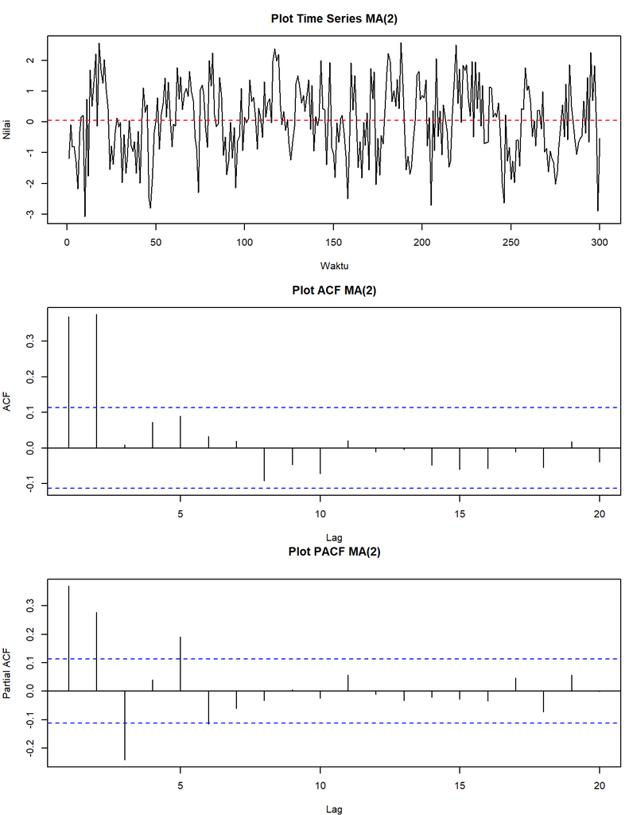

```r
plot_eksplorasi(ma, "MA(2)")
```

```r
eacf(ma)
```

```
## AR/MA
##   0 1 2 3 4 5 6 7 8 9 10 11 12 13
## 0 x x o o o o o o o o o  o  o  o
## 1 x x o o o o o o o o o  o  o  o
## 2 x x x x o o o x o o o  o  o  o
## 3 x x x o x o o o o o o  o  o  o
## 4 x x x o x x o o o o o  o  o  o
## 5 x x x x x x o o o o o  o  o  o
## 6 x o x o x x o o o o o  o  o  o
## 7 x x o o x x o o x o o  o  o  o
```

```r
st_ma <- cek_stasioner(ma)
```

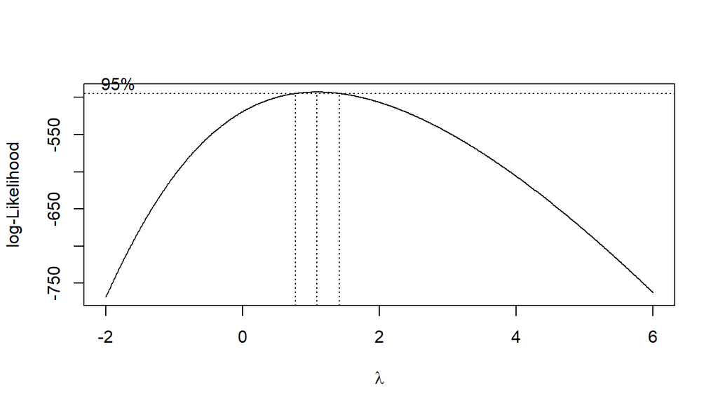

```r
st_ma$adf
```

```
##
##  Augmented Dickey-Fuller Test
##
## data:  y
## Dickey-Fuller = -5.9761, Lag order = 6, p-value = 0.01
## alternative hypothesis: stationary
```

```r
st_ma$lambda
```

```
## [1] 1.09
```

```r
st_ma$ci
```

```
## Batas_Bawah  Batas_Atas
##        0.78        1.41
```

**Identifikasi:**

- Plot time series menunjukkan data berfluktuasi di sekitar nilai tengahnya (0.052) dengan lebar fluktuasi yang relatif sama sepanjang waktu, sehingga secara eksplorasi data stasioner dalam rataan dan ragam.
- Plot ACF *cuts off* setelah lag ke-2, sedangkan plot PACF cenderung *tails off*. Pola ini sesuai dengan karakteristik MA(2).
- Pada EACF, segitiga nol (`o`) berawal pada baris AR = 0 dan kolom MA = 2, sehingga EACF menyarankan model ARMA(0,2) atau MA(2), sesuai dengan model yang dibangkitkan.
- Uji ADF — $H_0$: data tidak stasioner dalam rataan, $H_1$: data stasioner dalam rataan. Diperoleh *p-value* sebesar 0.01 < 0.05 sehingga tolak $H_0$: data **stasioner dalam rataan**.
- Box-Cox memberikan $\lambda$ optimum 1.09 dengan selang kepercayaan 95% [0.78, 1.41], yang memuat nilai 1 sehingga data **stasioner dalam ragam**.

Secara teoritis, proses MA berorde hingga **selalu stasioner** untuk nilai $\theta$ berapa pun, sehingga hasil di atas sesuai dengan teori.

## Scatterplot $Y_t$ dengan $Y_{t-1}$, $Y_{t-2}$, dan $Y_{t-3}$

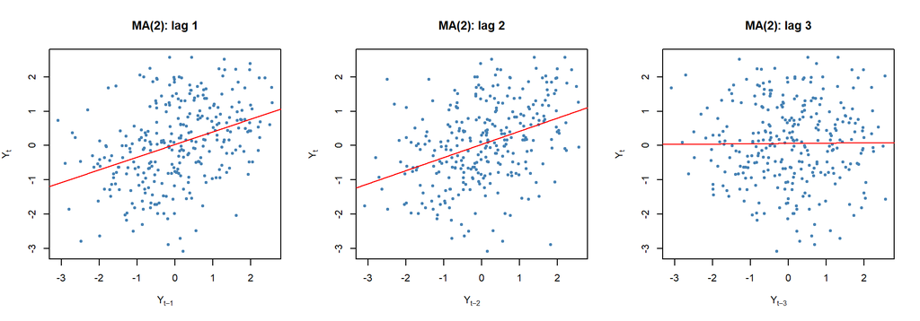

```r
scatter_lag(ma, "MA(2)")
```

Scatterplot lag 1 dan lag 2 menunjukkan hubungan positif, sedangkan pada lag 3 titik-titik menyebar acak tanpa pola (tidak ada hubungan).

## Autokorelasi

Autokorelasi teoritis MA(2):

$$\rho_1 = \frac{\theta_1 +
\theta_1\theta_2}{1+\theta_1^2+\theta_2^2} = \frac{0.4 + 0.24}{1.52} =
0.4211, \quad
\rho_2 = \frac{\theta_2}{1+\theta_1^2+\theta_2^2} = \frac{0.6}{1.52} =
0.3947, \quad
\rho_k = 0 \text{ untuk } k \ge 3$$

```r
ak_ma <- tabel_autokorelasi(ma, ma = c(0.4, 0.6))
ak_ma
```

```
##   Lag Korelasi_Pasangan ACF_Sampel ACF_Teoritis
## 1   1            0.3703     0.3695       0.4211
## 2   2            0.3801     0.3753       0.3947
## 3   3            0.0094     0.0093       0.0000
```

Autokorelasi data bangkitan pada lag 1 dan 2 bernilai cukup dekat dengan nilai teoritisnya, dan pada lag 3 mendekati nol sesuai teori ($\rho_3 = 0$). Perbedaan kecil muncul karena keragaman sampel.

# 2. Proses AR(2)

Model: $Y_t = 0.5\,Y_{t-1} + 0.2\,Y_{t-2} + e_t$

## Pembangkitan Data

### Manual

```r
wn_ar <- rnorm(n)
ar <- wn_ar[1:2]
for (i in 3:n) {
  ar[i] <- 0.5 * ar[i - 1] + 0.2 * ar[i - 2] + wn_ar[i]
}
ar <- ts(ar)
head(ar)
```

```
## Time Series:
## Start = 1
## End = 6
## Frequency = 1
## [1] -0.59376957 -0.97818347  1.11339990  1.01342167  0.36105474  0.08711908
```

### Dengan `arima.sim`

```r
ar_sim <- arima.sim(list(order = c(2, 0, 0), ar = c(0.5, 0.2)), n = n)
head(ar_sim)
```

```
## Time Series:
## Start = 1
## End = 6
## Frequency = 1
## [1]  1.57551894 -0.46028300 -0.29830718 -1.05198749 -0.15977853  0.04330006
```

## Plot Time Series, ACF, PACF, dan EACF

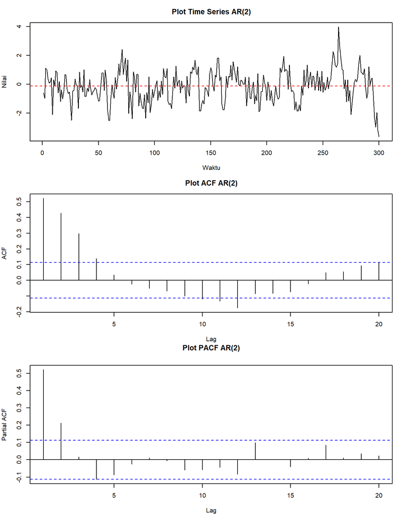

```r
plot_eksplorasi(ar, "AR(2)")
```

```r
eacf(ar)
```

```
## AR/MA
##   0 1 2 3 4 5 6 7 8 9 10 11 12 13
## 0 x x x x o o o o o x x  x  o  o
## 1 x o o o o o o o o o o  x  o  o
## 2 o x o o o o o o o o o  x  o  o
## 3 x x x o o o o o o o o  x  o  o
## 4 x x o o o o o o o o o  x  o  o
## 5 x x o o o o o o o o o  o  o  o
## 6 o x o o o o o o o o o  o  o  o
## 7 x o o x x o o o o o o  o  o  o
```

```r
st_ar <- cek_stasioner(ar)
```

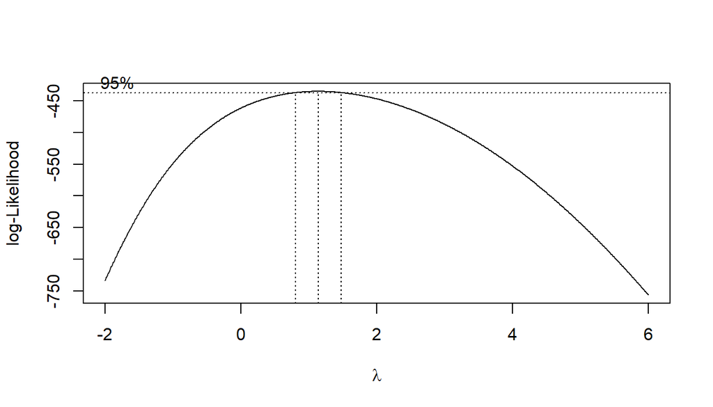

```r
st_ar$adf
```

```
##
##  Augmented Dickey-Fuller Test
##
## data:  y
## Dickey-Fuller = -5.286, Lag order = 6, p-value = 0.01
## alternative hypothesis: stationary
```

```r
st_ar$lambda
```

```
## [1] 1.14
```

```r
st_ar$ci
```

```
## Batas_Bawah  Batas_Atas
##        0.81        1.47
```

**Identifikasi:**

- Plot time series menunjukkan data berfluktuasi di sekitar nilai tengahnya (-0.132) dengan lebar fluktuasi yang relatif sama, sehingga secara eksplorasi data stasioner dalam rataan dan ragam.
- Plot ACF *tails off* (menurun perlahan secara eksponensial), sedangkan plot PACF *cuts off* setelah lag ke-2. Pola ini sesuai dengan karakteristik AR(2).
- Secara teori, segitiga nol pada EACF berawal pada baris AR = 2 dan kolom MA = 0. Pada data ini, baris AR = 0 dan AR = 2 masih memuat beberapa `x` di awal, sedangkan segitiga nol paling jelas berawal pada baris AR = 1 kolom MA = 1, sehingga EACF menyarankan ARMA(1,1) sebagai kandidat. EACF hanya memberi kandidat model; orde AR(2) tetap terlihat jelas dari PACF yang *cuts off* setelah lag 2.
- Uji ADF memberikan *p-value* sebesar 0.01 < 0.05 sehingga tolak $H_0$: data **stasioner dalam rataan**.
- Box-Cox memberikan $\lambda$ optimum 1.14 dengan selang kepercayaan 95% [0.81, 1.47], yang memuat nilai 1 sehingga data **stasioner dalam ragam**.

Secara teoritis, AR(2) stasioner jika $\phi_1 + \phi_2 < 1$, $\phi_2 - \phi_1 < 1$, dan $|\phi_2| < 1$. Dengan $\phi_1 = 0.5$ dan $\phi_2 = 0.2$: $0.7 < 1$, $-0.3 < 1$, dan $0.2 < 1$, sehingga ketiga syarat terpenuhi. Hal ini juga dapat dicek dari akar polinomial karakteristik yang seluruhnya berada di luar lingkaran satuan:

```r
Mod(polyroot(c(1, -0.5, -0.2)))
```

```
## [1] 1.311738 3.811738
```

## Scatterplot $Y_t$ dengan $Y_{t-1}$, $Y_{t-2}$, dan $Y_{t-3}$

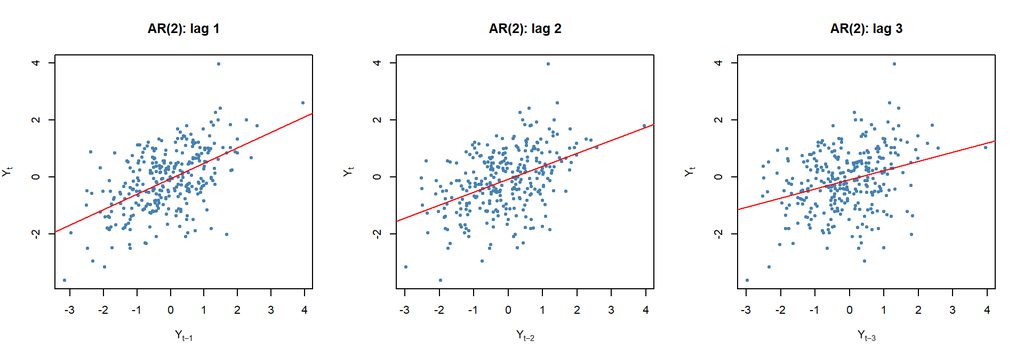

```r
scatter_lag(ar, "AR(2)")
```

Ketiga scatterplot menunjukkan hubungan positif yang semakin melemah seiring bertambahnya lag, sesuai dengan ACF AR yang meluruh secara eksponensial.

## Autokorelasi

Autokorelasi teoritis AR(2) mengikuti persamaan Yule-Walker:

$$\rho_1 = \frac{\phi_1}{1-\phi_2} =
\frac{0.5}{0.8} = 0.625, \quad
\rho_2 = \phi_1\rho_1 + \phi_2 = 0.5125, \quad
\rho_3 = \phi_1\rho_2 + \phi_2\rho_1 = 0.3813$$

```r
ak_ar <- tabel_autokorelasi(ar, ar = c(0.5, 0.2))
ak_ar
```

```
##   Lag Korelasi_Pasangan ACF_Sampel ACF_Teoritis
## 1   1            0.5314     0.5218       0.6250
## 2   2            0.4418     0.4274       0.5125
## 3   3            0.3107     0.2983       0.3812
```

Autokorelasi data bangkitan mengikuti pola teoritis, yaitu positif dan menurun seiring bertambahnya lag, dengan selisih kecil akibat keragaman sampel.

# 3. Proses ARMA(2,2)

Model: $Y_t = 0.5\,Y_{t-1} + 0.2\,Y_{t-2} + e_t + 0.4\,e_{t-1} + 0.6\,e_{t-2}$

## Pembangkitan Data

### Manual

```r
wn_arma <- rnorm(n)
arma <- wn_arma[1:2]
for (i in 3:n) {
  arma[i] <- 0.5 * arma[i - 1] + 0.2 * arma[i - 2] +
    wn_arma[i] + 0.4 * wn_arma[i - 1] + 0.6 * wn_arma[i - 2]
}
arma <- ts(arma)
head(arma)
```

```
## Time Series:
## Start = 1
## End = 6
## Frequency = 1
## [1]  1.3152700  0.1865044  0.4752643 -0.3833121 -0.5850357 -0.1082029
```

### Dengan `arima.sim`

```r
arma_sim <- arima.sim(list(order = c(2, 0, 2), ar = c(0.5, 0.2), ma = c(0.4, 0.6)), n = n)
head(arma_sim)
```

```
## Time Series:
## Start = 1
## End = 6
## Frequency = 1
## [1] -0.9691059 -2.6131592 -1.0000374 -2.6456619 -1.8420746 -0.5577747
```

## Plot Time Series, ACF, PACF, dan EACF

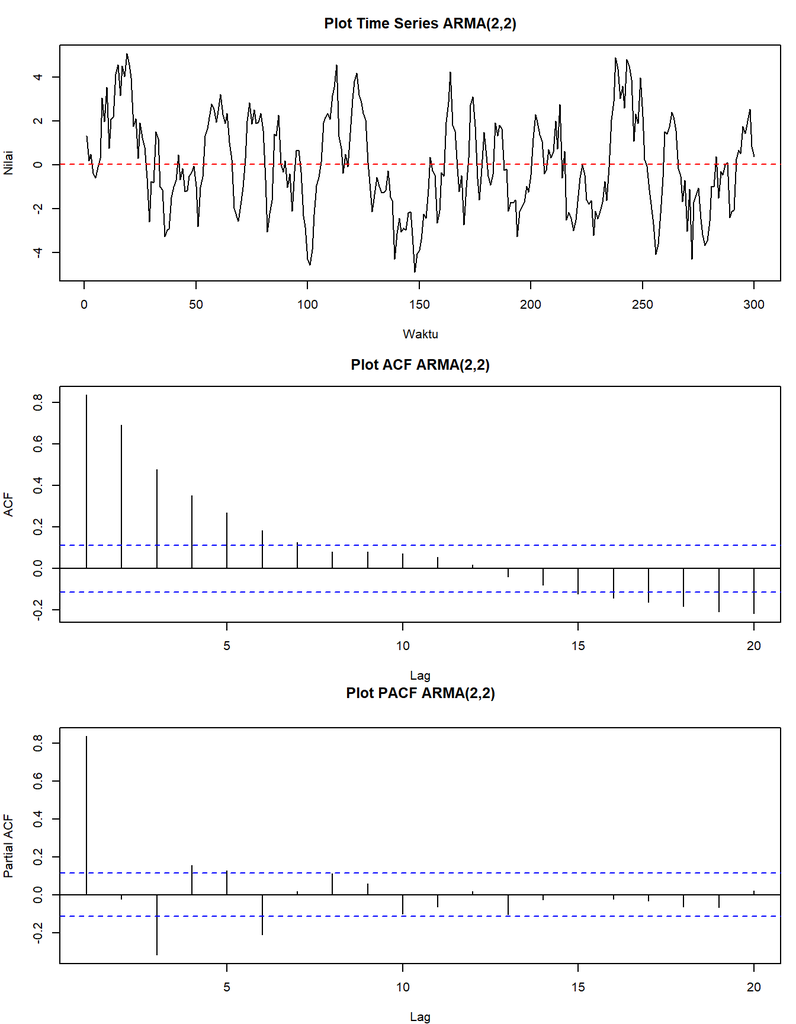

```r
plot_eksplorasi(arma, "ARMA(2,2)")
```

```r
eacf(arma)
```

```
## AR/MA
##   0 1 2 3 4 5 6 7 8 9 10 11 12 13
## 0 x x x x x x x o o o o  o  o  o
## 1 o x o o o o o x o o o  o  o  o
## 2 o x x o o o o x o o o  o  o  o
## 3 x x o o x o o o o o o  o  o  o
## 4 x x x o o o o o o o o  o  o  o
## 5 x x x o o o o o o o o  o  o  o
## 6 o x x o x o o o o o o  o  o  o
## 7 x x x o o o o o o o o  o  o  o
```

```r
st_arma <- cek_stasioner(arma)
```

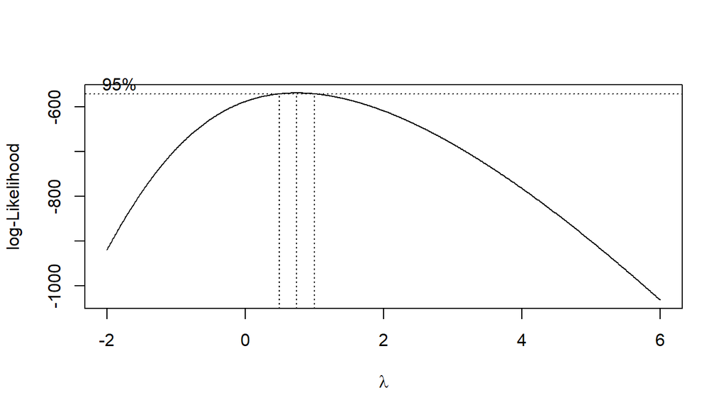

```r
st_arma$adf
```

```
##
##  Augmented Dickey-Fuller Test
##
## data:  y
## Dickey-Fuller = -5.0961, Lag order = 6, p-value = 0.01
## alternative hypothesis: stationary
```

```r
st_arma$lambda
```

```
## [1] 0.74
```

```r
st_arma$ci
```

```
## Batas_Bawah  Batas_Atas
##        0.50        0.99
```

**Identifikasi:**

- Plot time series menunjukkan data berfluktuasi di sekitar nilai tengahnya (0.021) dengan lebar fluktuasi yang relatif sama, sehingga secara eksplorasi data stasioner dalam rataan dan ragam.
- Plot ACF dan PACF sama-sama *tails off*, yang merupakan ciri proses ARMA. Karena keduanya *tails off*, orde model sulit ditentukan hanya dari ACF dan PACF, sehingga digunakan EACF.
- Secara teori, segitiga nol pada EACF berawal pada baris AR = 2 dan kolom MA = 2. Pada data ini, segitiga nol berawal di sekitar baris AR = 1 kolom MA = 2 (masih ada `x` pada kolom MA = 7), sehingga kandidat yang disarankan adalah ARMA(1,2), bersebelahan dengan model sebenarnya ARMA(2,2). Pergeseran ini wajar karena keragaman sampel.
- Uji ADF memberikan *p-value* sebesar 0.01 < 0.05 sehingga tolak $H_0$: data **stasioner dalam rataan**.
- Box-Cox memberikan $\lambda$ optimum 0.74 dengan selang kepercayaan 95% [0.5, 0.99], yang tidak memuat nilai 1 sehingga data belum stasioner dalam ragam.

> **Catatan Box-Cox:** data ARMA bernilai negatif sehingga harus digeser dengan konstanta sebelum Box-Cox, dan nilai $\lambda$ sensitif terhadap besar konstanta tersebut. Jika selang kepercayaan tidak memuat 1 tetapi batasnya sangat dekat dengan 1 (seperti di atas) dan plot time series tidak menunjukkan perubahan lebar fluktuasi, hasil tersebut lebih tepat dianggap sebagai efek pergeseran data dan keragaman sampel, bukan bukti ketidakstasioneran ragam.

Kestasioneran ARMA hanya ditentukan oleh komponen AR-nya. Komponen AR di sini sama dengan proses AR(2) di atas yang memenuhi syarat stasioner, sehingga ARMA(2,2) ini juga **stasioner**.

## Scatterplot $Y_t$ dengan $Y_{t-1}$, $Y_{t-2}$, dan $Y_{t-3}$

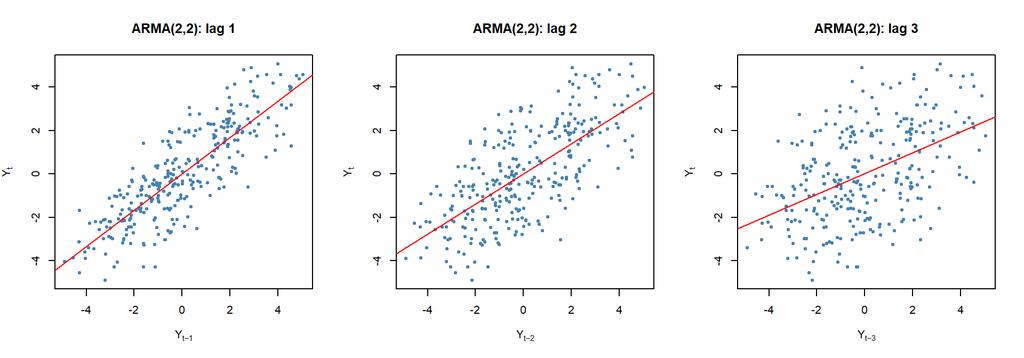

```r
scatter_lag(arma, "ARMA(2,2)")
```

Ketiga scatterplot menunjukkan hubungan positif yang kuat dan melemah perlahan seiring bertambahnya lag.

## Autokorelasi

Autokorelasi teoritis ARMA(2,2) dihitung dengan fungsi `ARMAacf()`. Untuk $k > 2$ (melewati orde MA), autokorelasi mengikuti persamaan rekursif $\rho_k = \phi_1\rho_{k-1} + \phi_2\rho_{k-2}$.

```r
ak_arma <- tabel_autokorelasi(arma, ar = c(0.5, 0.2), ma = c(0.4, 0.6))
ak_arma
```

```
##   Lag Korelasi_Pasangan ACF_Sampel ACF_Teoritis
## 1   1            0.8366     0.8360       0.8592
## 2   2            0.6923     0.6917       0.7492
## 3   3            0.4778     0.4763       0.5464
```

Autokorelasi data bangkitan mengikuti pola teoritis: bernilai positif tinggi dan menurun perlahan seiring bertambahnya lag.

# Kesimpulan

```r
rbind(
  data.frame(Model = "MA(2)", ak_ma),
  data.frame(Model = "AR(2)", ak_ar),
  data.frame(Model = "ARMA(2,2)", ak_arma)
)
```

```
##        Model Lag Korelasi_Pasangan ACF_Sampel ACF_Teoritis
## 1      MA(2)   1            0.3703     0.3695       0.4211
## 2      MA(2)   2            0.3801     0.3753       0.3947
## 3      MA(2)   3            0.0094     0.0093       0.0000
## 11     AR(2)   1            0.5314     0.5218       0.6250
## 21     AR(2)   2            0.4418     0.4274       0.5125
## 31     AR(2)   3            0.3107     0.2983       0.3812
## 12 ARMA(2,2)   1            0.8366     0.8360       0.8592
## 22 ARMA(2,2)   2            0.6923     0.6917       0.7492
## 32 ARMA(2,2)   3            0.4778     0.4763       0.5464
```

| Model | ACF | PACF | Stasioner |
| --- | --- | --- | --- |
| MA(2) | *cuts off* setelah lag 2 | *tails off* | Ya (MA selalu stasioner) |
| AR(2) | *tails off* | *cuts off* setelah lag 2 | Ya ($\phi_1+\phi_2<1$, $\phi_2-\phi_1<1$, $\|\phi_2\|<1$) |
| ARMA(2,2) | *tails off* | *tails off* | Ya (komponen AR stasioner) |

Uji ADF menunjukkan ketiga data bangkitan stasioner dalam rataan. Box-Cox mendukung kestasioneran ragam pada MA(2) dan AR(2); pada ARMA(2,2) selang kepercayaan $\lambda$ nyaris memuat 1 dan plot time series tetap menunjukkan ragam yang konstan, sesuai teori bahwa ketiga proses stasioner. Autokorelasi sampel mengikuti pola teoritis masing-masing, dengan selisih akibat keragaman sampel.